# Coursera - Predictive Machine Learning MOOC - Course project

Stefano Merlo

04/11/2015

# Overview

Using devices such as Jawbone Up, Nike FuelBand, and Fitbit it is now possible to collect a large amount of data about personal activity relatively inexpensively. These type of devices are part of the quantified self movement – a group of enthusiasts who take measurements about themselves regularly to improve their health, to find patterns in their behavior, or because they are tech geeks. One thing that people regularly do is quantify how much of a particular activity they do, but they rarely quantify how well they do it. In this project, your goal will be to use data from accelerometers on the belt, forearm, arm, and dumbell of 6 participants. They were asked to perform barbell lifts correctly and incorrectly in 5 different ways. More information is available from the website here: http://groupware.les.inf.puc-rio.br/har (see the section on the Weight Lifting Exercise Dataset).

Goal of this project is to predict the manner in which the subjects did the exercise, by estimating the “classe” response variable.

# Data preparation and exploratory analysis

Focus of this analysis is on quantitative continuous data coming from activity sensors; all other variables (like timestamps) will be excluded from the model.

From a quick plot, many variables are almost completely missing values. All predictors with missing data (NAs) will be removed before testing models.

```r
# load libraries
require(caret)
```

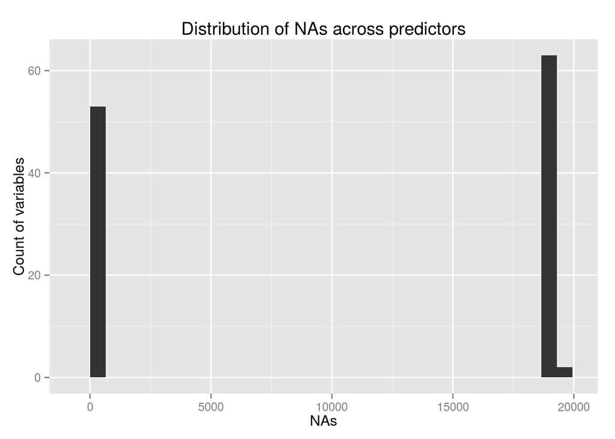

```r
set.seed(816)

# download data sets
setwd("/home/erpreciso/Documents/school")
download.file("https://d396qusza40orc.cloudfront.net/predmachlearn/pml-training.csv", "temp", method="curl")
download.file("https://d396qusza40orc.cloudfront.net/predmachlearn/pml-testing.csv", "temp2", method="curl")

# import data considering also DIV/0! strings as NAs
training <- read.csv("temp", na.strings=c("NA","#DIV/0!"))
testing <- read.csv("temp2", na.strings=c("NA","#DIV/0!"))

# find predictors with zero / near zero variance and mark for removal
nsv <- nearZeroVar(training, saveMetrics=TRUE)
to.eliminate <- row.names(nsv[nsv$nzv,])

# mark for removal some not meaningful variables
excl <- c("problem_id","X","user_name","raw_timestamp_part_1",
          "raw_timestamp_part_2","cvtd_timestamp","num_window")
to.eliminate <- c(to.eliminate, excl)

# remove variables marked
training <- training[, -which(names(training) %in% to.eliminate)]
testing <- testing[, -which(names(testing) %in% to.eliminate)]

# plot NAs distribution histogram
nas.dist <- apply(training,2, function(x) sum(is.na(x)))
qplot(nas.dist, geom="histogram", xlab="NAs", ylab="Count of variables", main="Distribution of NAs across predictors")
```

```r
# subset only predictors with NA values
nas <- !is.na(colSums(training[, -which(names(training)=="classe")]))
training <- training[,nas]
testing <- testing[,nas]

# find predictors with high correlation, and remove
training.cor <- abs(cor(training[, -which(names(training)=="classe")],
                        method="pearson"))
diag(training.cor) <- 0
high.cor <- which(training.cor > .8, arr.ind=TRUE)
training <- training[, -high.cor]
testing <- testing[, -high.cor]
```

# How the model is built, and how cross-validation is used

We’ll pass a request to perform a 5-folds cross-validation in training the model with the caret’s `trainControl` call.

```r
# create a validation subset to test different models
in.train <- createDataPartition(training$classe, p=0.8, list=FALSE)
ta <- training[in.train,]
te <- training[-in.train,]

# using cross-validation in the model
fc <- trainControl(method = "repeatedcv", number = 5, repeats = 5)
```

#### Linear Discriminant Analysis

This model is prefered when there’s the assumption that data are normally distributed, differently from this analysis, and look for combinations within variables.

```r
lda.fit <- train(classe~.,data=ta, method="lda", trControl=fc)
lda.metric <- confusionMatrix(predict(lda.fit, newdata=te), te$classe)
lda.metric
```

```
## Confusion Matrix and Statistics
##
##           Reference
## Prediction   A   B   C   D   E
##          A 759 205 102  32  36
##          B 134 314  51  64 126
##          C 130  88 433  90  87
##          D  66  93  72 392  84
##          E  27  59  26  65 388
##
## Overall Statistics
##
##                Accuracy : 0.5827
##                  95% CI : (0.5671, 0.5982)
##     No Information Rate : 0.2845
##     P-Value [Acc > NIR] : < 2.2e-16
##
##                   Kappa : 0.4724
##  Mcnemar's Test P-Value : < 2.2e-16
##
## Statistics by Class:
##
##                      Class: A Class: B Class: C Class: D Class: E
## Sensitivity            0.6801  0.41370   0.6330  0.60964   0.5381
## Specificity            0.8664  0.88148   0.8780  0.90396   0.9447
## Pos Pred Value         0.6693  0.45573   0.5229  0.55446   0.6867
## Neg Pred Value         0.8720  0.86240   0.9189  0.92195   0.9008
## Prevalence             0.2845  0.19347   0.1744  0.16391   0.1838
## Detection Rate         0.1935  0.08004   0.1104  0.09992   0.0989
## Detection Prevalence   0.2891  0.17563   0.2111  0.18022   0.1440
## Balanced Accuracy      0.7733  0.64759   0.7555  0.75680   0.7414
```

This method returns a poor accuracy: `0.58`

#### Regression Trees

This model is more oriented to find interactions between variables.

```r
rpart.fit <- train(classe~.,data=ta, method="rpart", trControl=fc)
rpart.metric <- confusionMatrix(predict(rpart.fit, newdata=te), te$classe)
rpart.metric
```

```
## Confusion Matrix and Statistics
##
##           Reference
## Prediction    A    B    C    D    E
##          A 1030  310  314  237  157
##          B   21  233   29   14  104
##          C   64  187  341  231  188
##          D    0   28    0  111   39
##          E    1    1    0   50  233
##
## Overall Statistics
##
##                Accuracy : 0.4966
##                  95% CI : (0.4808, 0.5123)
##     No Information Rate : 0.2845
##     P-Value [Acc > NIR] : < 2.2e-16
##
##                   Kappa : 0.3428
##  Mcnemar's Test P-Value : < 2.2e-16
##
## Statistics by Class:
##
##                      Class: A Class: B Class: C Class: D Class: E
## Sensitivity            0.9229  0.30698  0.49854  0.17263  0.32316
## Specificity            0.6373  0.94690  0.79315  0.97957  0.98376
## Pos Pred Value         0.5029  0.58105  0.33729  0.62360  0.81754
## Neg Pred Value         0.9541  0.85065  0.88221  0.85794  0.86586
## Prevalence             0.2845  0.19347  0.17436  0.16391  0.18379
## Detection Rate         0.2626  0.05939  0.08692  0.02829  0.05939
## Detection Prevalence   0.5220  0.10222  0.25771  0.04537  0.07265
## Balanced Accuracy      0.7801  0.62694  0.64584  0.57610  0.65346
```

#### Gradient Boosting Machine

Another model tested is Gradient Boosting Machine, that uses regression trees to predict probabilities.

```r
gbm.fit <- train(classe~.,data=ta, method="gbm", verbose=FALSE, trControl=fc)
gbm.metric <- confusionMatrix(predict(gbm.fit, newdata=te), te$classe)
gbm.metric
```

```
## Confusion Matrix and Statistics
##
##           Reference
## Prediction    A    B    C    D    E
##          A 1092   48   12    2    3
##          B   10  646   42    8   18
##          C    7   45  614   47   18
##          D    6   11   12  574   17
##          E    1    9    4   12  665
##
## Overall Statistics
##
##                Accuracy : 0.9154
##                  95% CI : (0.9062, 0.9239)
##     No Information Rate : 0.2845
##     P-Value [Acc > NIR] : < 2.2e-16
##
##                   Kappa : 0.8928
##  Mcnemar's Test P-Value : 8.472e-10
##
## Statistics by Class:
##
##                      Class: A Class: B Class: C Class: D Class: E
## Sensitivity            0.9785   0.8511   0.8977   0.8927   0.9223
## Specificity            0.9768   0.9753   0.9639   0.9860   0.9919
## Pos Pred Value         0.9438   0.8923   0.8399   0.9258   0.9624
## Neg Pred Value         0.9913   0.9647   0.9781   0.9791   0.9827
## Prevalence             0.2845   0.1935   0.1744   0.1639   0.1838
## Detection Rate         0.2784   0.1647   0.1565   0.1463   0.1695
## Detection Prevalence   0.2949   0.1846   0.1863   0.1580   0.1761
## Balanced Accuracy      0.9777   0.9132   0.9308   0.9393   0.9571
```

This returns a very good accuracy, and it will be chosen for the test prediction: `0.92`

# Expected out of sample error

From the accuracy returned by the model testing on the validation set, a `8%` of out-of-sample error is expected.

# Actual data prediction

Testing data will be predicted and saved into `gbm.prediction`.

```r
gbm.prediction <- predict(gbm.fit, newdata=testing)
```

# Resources

Paper (link)[http://groupware.les.inf.puc-rio.br/work.jsf?p1=11201]

Velloso, E.; Bulling, A.; Gellersen, H.; Ugulino, W.; Fuks, H. Qualitative Activity Recognition of Weight Lifting Exercises. Proceedings of 4th International Conference in Cooperation with SIGCHI (Augmented Human ’13) . Stuttgart, Germany: ACM SIGCHI, 2013.

http://groupware.les.inf.puc-rio.br/public/papers/2013.Velloso.QAR-WLE.pdf